[figure not shown]

```r
options(scipen = 999)

library(tidyverse)
library(readxl)
library(urbnthemes)

set_urbn_defaults("print")
```

# Measuring homeownership with the CPS

## Set up

Load libraries

```r
library(tidyverse)
library(readxl)
```

Create directories for data.

```r
if (!dir.exists("data")) {
  dir.create("data")
}
```

## Download the data

We will use two tables for this:

1. Table 14: Quarterly Homeownership Rates for the U.S. and Regions: 1964 to Present
2. Table B-5. Margins of Error of Homeownership Rates for the United States

```r
if (!file.exists("data/histtab14.xlsx")) {

  download.file(url = "https://www.census.gov/housing/hvs/data/histtab14.xlsx",
                destfile = "data/histtab14.xlsx",
                mode="wb")

}

if (!file.exists("data/B5.xlsx")) {

  download.file(url = "https://www.census.gov/housing/hvs/data/B5.xlsx",
                destfile = "data/B5.xlsx",
                mode="wb")

}
```

## Read and clean

### Homeownership rate

First, read in and clean up the homeownership rate data.

```r
rate <- read_excel("data/histtab14.xlsx",
                   skip = 3)

# Get rid of rows of footnotes
rate <- rate %>%
  head(-6)
```

The year and region variables share a column. Extract the year bu coercing a new year variable into an integer (this will drop the region names), and fill each region with the correct year.

```r
rate <- rate %>%
  mutate(year = as.integer(`Year and Area`)) %>%
  filter(!is.na(`Year and Area`)) %>%
  fill(year, .direction = "down") %>%
  filter(str_detect(`Year and Area`, "[:digit:]") == FALSE)
```

There are three years that have revisions, so they are duplicated. Get only the revised estimates- these are listed after the unrevised estimates. Get the second set of estimates, and merge them back onto the master data.

```r
# Get only second set
rev <- rate %>%
  group_by(year) %>%
  filter(n() > 5) %>%
  mutate(num = row_number()) %>%
  filter(num %in% 6:10) %>%
  select(-num)

rate <- rate %>%
  filter(!year %in% unique(rev$year)) %>%
  bind_rows(rev)

stopifnot(
  rate %>% group_by(year) %>% filter(n() > 5) %>% nrow() == 0
)

rm(rev)
```

Fix the region names, reshape, format date variable, convert homeownership rate to percent.

```r
names(rate) <- c("region", "Q1", "Q2", "Q3", "Q4", "year")

rate <- rate %>%
  mutate(region = str_remove_all(region, "[:punct:]")) %>%
  gather(key = "quarter", value = "horate", -region, -year) %>%
  arrange(region, year, quarter) %>%
  mutate(period = paste0(year, quarter),
         date = lubridate::yq(period),
         horate = horate / 100)
```

### Margin of error

Repeat a similar process for the margin of error.

```r
margin <- read_excel("data/B5.xlsx", skip = 7,
                     col_names = c("year", "Q1", "Q2", "Q3", "Q4")) %>%
  head(-5)
```

Clean up year variable, reshape, format date variable. The margin of error represents the 90 percent confidence interval in percent- divide by 100.

```r
margin <- margin %>%
  mutate(year = str_remove_all(year, "[:punct:]")) %>%
  gather(key = "quarter", value = "margin_error", -year) %>%
  mutate(period = paste0(year, quarter),
         date = lubridate::yq(period),
         year = as.integer(year),
         margin_error = margin_error / 100)
```

### Combine

Filter only national observations, merge with margin of error. Select only observations after 2000. Create variables that represent the bottom and top of the 90% interval.

Calculate two additional variables- the year-over-year change, and the quarter to quarter change.

```r
cps <- rate %>%
  filter(region == "United States") %>%
  left_join(margin, by = c("year", "quarter", "period", "date")) %>%
  filter(year >= 2000) %>%
  mutate(horate_low = horate - margin_error,
         horate_high = horate + margin_error,
         horate_yoy = horate / lag(horate, 4) - 1,
         horate_mom = horate - lag(horate, 1))
```

## Analyze series

Plot the series over time.

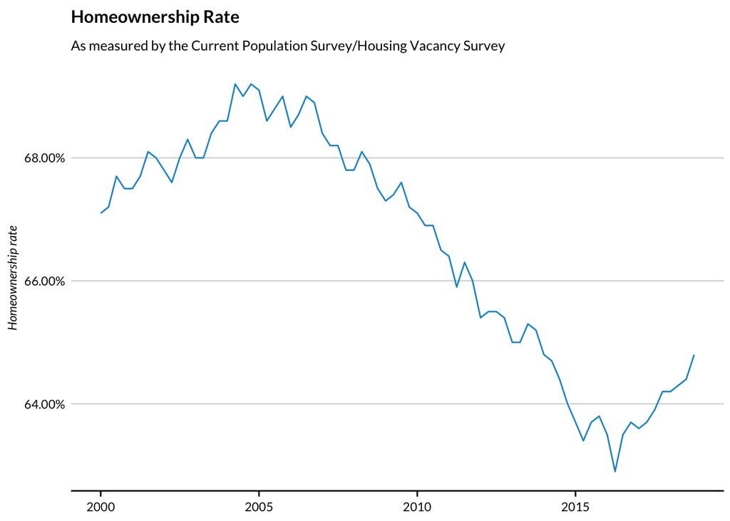

```r
ggplot(data = cps, mapping = aes(date, horate)) +
  geom_line() +
  scale_y_continuous(labels = scales::percent) +
  labs(x = NULL, y = "Homeownership rate",
       title = "Homeownership Rate",
       subtitle = "As measured by the Current Population Survey/Housing Vacancy Survey")
```

Add error bars.

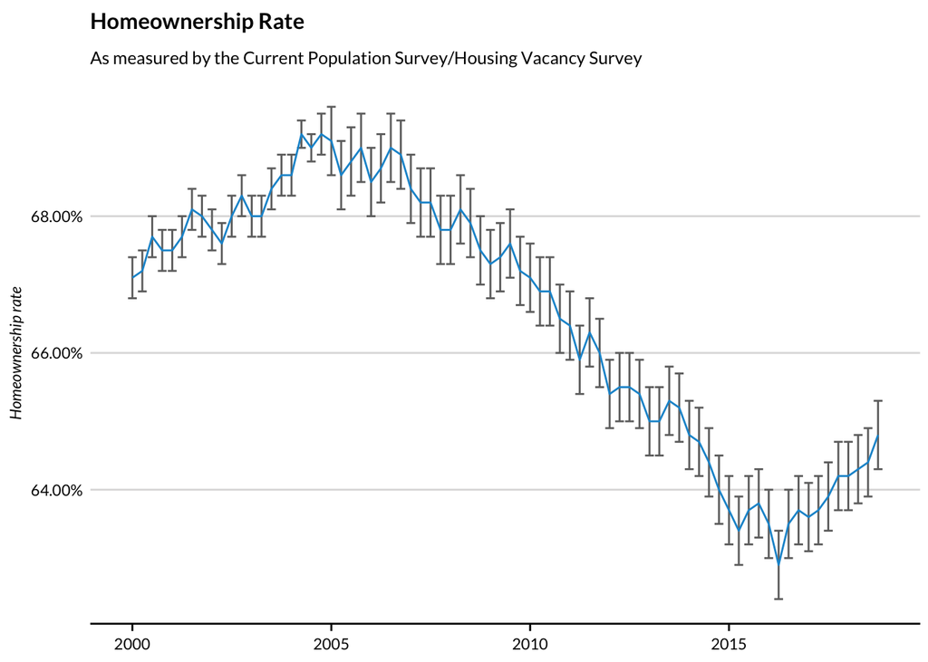

```r
ggplot(data = cps, mapping = aes(date, horate)) +
  geom_errorbar(aes(ymin = horate_low, ymax = horate_high),
                color = "#6f6f6f") +
  geom_line() +
  scale_y_continuous(labels = scales::percent) +
  labs(x = NULL, y = "Homeownership rate",
       title = "Homeownership Rate",
       subtitle = "As measured by the Current Population Survey/Housing Vacancy Survey")
```

Shade the 90% confidence interval.

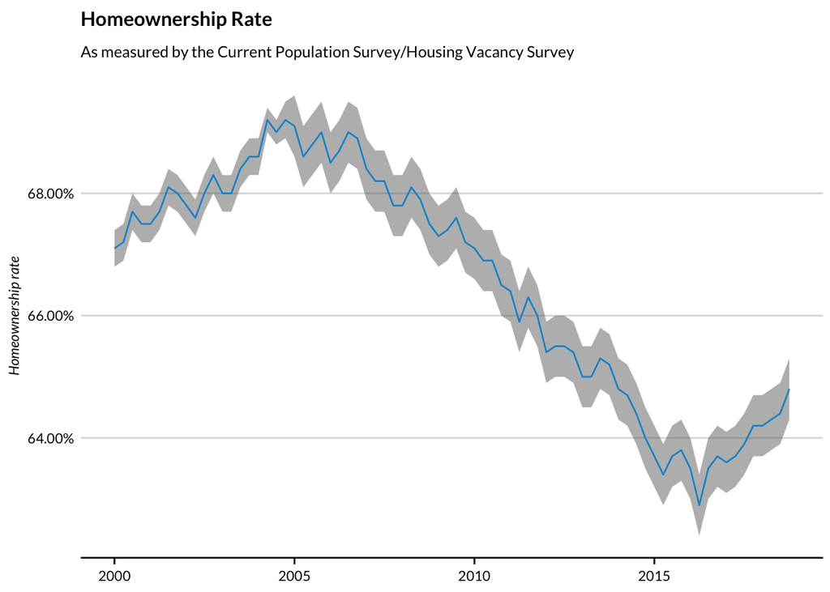

```r
ggplot(data = cps, mapping = aes(date, horate)) +
  geom_ribbon(aes(ymin = horate_low, ymax = horate_high),
                fill = "#6f6f6f", alpha = .5) +
  geom_line() +
  scale_y_continuous(labels = scales::percent) +
  labs(x = NULL, y = "Homeownership rate",
       title = "Homeownership Rate",
       subtitle = "As measured by the Current Population Survey/Housing Vacancy Survey")
```